# Analysis Of RNA-seq Data Using R

Nadia Atallah Lanman  
November 19, 2019

### Central Dogma of Molecular Biology

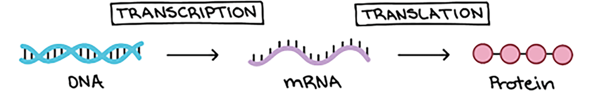

- By measuring how many mRNA molecules there are for each gene, we can quantify which genes are “on” or “off”

### Why do gene expression analyses?

- Now feasible and simple to measure the expression levels of thousands of genes simultaneously
- Gene Annotation
- Functional studies
- Some molecular features are only seen at RNA level

### Several types of gene expression analyses

- qRT-PCR
- microarray
- RNA-seq
  - bulk
  - single-cell

### RNA-Seq

- High-throughput sequencing of RNA
- Allows for quantification of gene expression and differential expression analyses
- Characterization of alternative splicing
- de novo transcriptome assembly
  - no genome sequence necessary!

### Basic RNA-seq Protocol

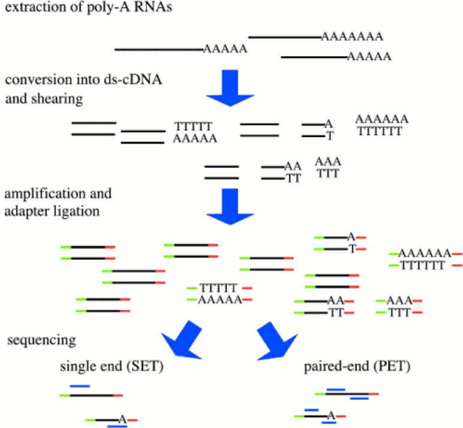

### Terminology

- Reads = the sequenced portion of cDNA fragments
- Depth= (read length)(number of reads) / (haploid genome length)
- Single-end= cDNA fragments are sequenced from only one end (1x100)
- Paired-end= cDNA fragments are sequenced from both ends (2x100)
- Strand-specific= you know whether the read originated from the + or - strand

### FASTQ file format

- Raw sequence data generally is in FASTQ format
  - Text files with both sequence and quality information
  - Integer scores converted to ASCII characters

\[ Q = -10log_{10}P \]

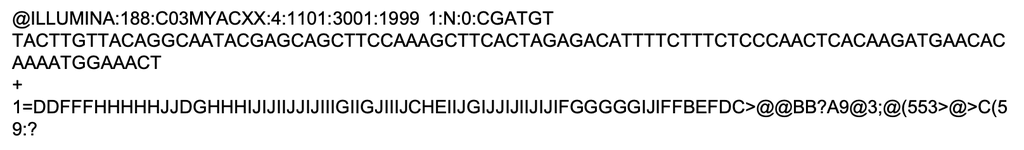

### Basic RNA-seq analysis workflow

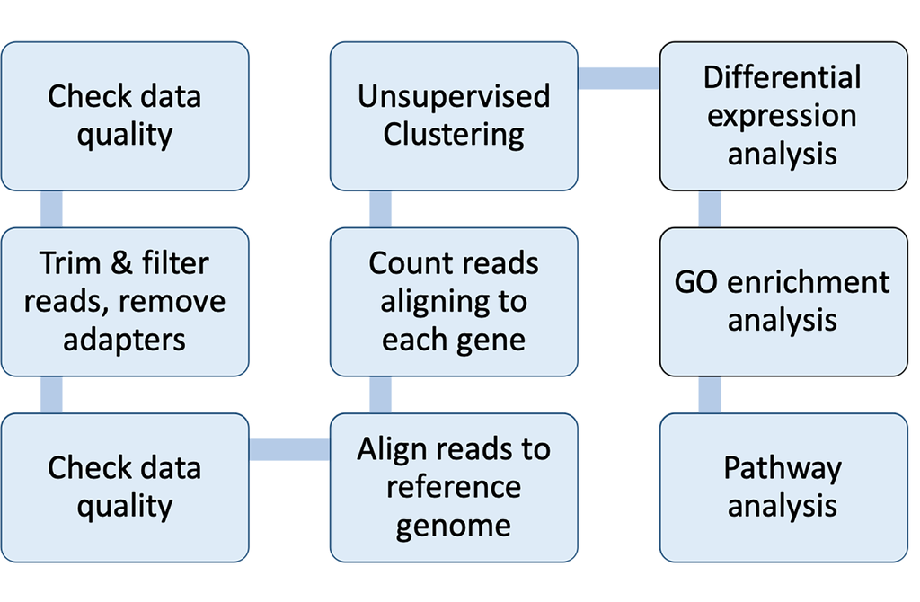

### Install TCGAbiolinks

```r
#install.packages("BiocManager")
#BiocManager::install("TCGAbiolinks")

library(TCGAbiolinks)
#citation("TCGAbiolinks")
```

- TCGAbiolinks is a package for accessing and doing basic analyses on TCGA (The Cancer Genome Atlas) data.
- TCGA data surveys over 33 different tumor types
  - Allows comparisons to be made between cancer and normal tumors

### Install SummarizedExperiment

```r
#BiocManager::install("SummarizedExperiment")

library(SummarizedExperiment)
```

- The SummarizedExperiment Class is a container to store matrices of experimental results and is often used to store gene expression data (as well as other sequencing-related datasets)
- This container is very helpful in keeping experimental data and meta data in sync

### Download TCGA Count Data

- Use the Genomic Data Commons to search for TCGA data for prostate cancer

```r
# Gene expression aligned against hg38
query.counts <- GDCquery(project = "TCGA-PRAD",
                  data.category = "Transcriptome Profiling",
                  data.type = "Gene Expression Quantification",
                  workflow.type="HTSeq - Counts")
GDCdownload(query.counts)
#read the downloaded data and prepare in into an R object
data.counts <- GDCprepare(query.counts)
```

[output not shown]

[output cut: 497 more lines]

[output not shown]

### Download TCGA Clinical Data

```r
# Biospecimen Data
query.biospecimen <- GDCquery(project = "TCGA-PRAD",
                           data.category = "Biospecimen",
                           file.type = "xml")
GDCdownload(query.biospecimen)
prad.biospec <- GDCprepare_clinic(query.biospecimen,clinical.info = "sample")
#write.csv(prad.biospec, "Biospecimen_prad.csv")
```

### Prepare a count matrix

```r
counts <- assay(data.counts, "HTSeq - Counts")
dim(counts)
```

```
[1] 56512   551
```

```r
#write.csv(counts, file = "all.prad.htseq.counts.csv")
coldata<-(colData(data.counts))
```

- Genes are in rows and samples are in columns
- Data is raw counts generated using a program called [HTSeq](https://htseq.readthedocs.io/en/release_0.11.1/)

### Sample Barcodes

```r
colnames(counts)[1:5]
```

```
[1] "TCGA-YL-A8SI-01A-11R-A41O-07" "TCGA-V1-A8WW-01A-11R-A37L-07"
[3] "TCGA-KK-A6E5-01A-11R-A311-07" "TCGA-HC-A6HY-01A-11R-A31N-07"
[5] "TCGA-KK-A8IG-01A-11R-A36G-07"
```

- Tumor types range from 01 - 09, normal types from 10 - 19 and control samples from 20 - 29. See codes for more details

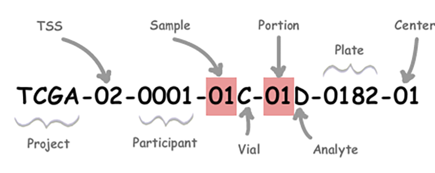

### Separate the Samples

- Keep tumor samples only

```r
tumor.counts <- counts[ , grepl( "-01A" , colnames( counts ) ) ]
dim(tumor.counts)
```

```
[1] 56512   481
```

```r
colnames(tumor.counts) <- sapply(strsplit(colnames(tumor.counts), "-"), function(x) paste0(x[1:3], collapse = "-"))
#write.csv(prad.biospec, "Biospecimen_prad.csv")
col.gleason<-coldata[!is.na(coldata$subtype_Clinical_Gleason_sum),]
#write.csv(coldata, "prad.coldata.csv")
```

### Separate the Samples

- Separate the samples into high and low gleason score

```r
#make matrix of patients with gleason>=8
hi.gleason <- col.gleason[col.gleason$subtype_Clinical_Gleason_sum >= 8,]
dim(hi.gleason)
```

```
[1] 106 152
```

### Separate the Samples

- Separate the samples into high and low gleason score

```r
#make a matrix of patients with gleason<8
lo.gleason <- col.gleason[col.gleason$subtype_Clinical_Gleason_sum < 8,]
dim(lo.gleason)
```

```
[1] 175 152
```

### Separate the Samples

```r
#make a count matrix of low and high gleason score patients
lo.counts<- tumor.counts[,which(colnames(tumor.counts) %in% lo.gleason$bcr_patient_barcode)]
hi.counts<- tumor.counts[,which(colnames(tumor.counts) %in% hi.gleason$bcr_patient_barcode)]
dim(lo.counts)
```

```
[1] 56512   170
```

```r
dim(hi.counts)
```

```
[1] 56512    97
```

```r
prad.counts<-cbind(lo.counts,hi.counts)
```

### edgeR

```r
#BiocManager::install("edgeR")
library(edgeR)
#citation("edgeR")
library(ggplot2)
```

-Originally developed for differential expression analysis of RNA-seq data with biological replication

- Can also be used for a variety of count based data genomic data, such as Bisulfite-seq and ChIP-seq
  - Implements statistical methods based on the negative binomial distribution as a model for count variability
- Includes empirical Bayes methods, exact test, and GLMs

### Remove zero count genes

```r
countsNozero=prad.counts[rowSums(prad.counts)!=0,]
dim(prad.counts)
```

```
[1] 56512   267
```

```r
dim(countsNozero)
```

```
[1] 53891   267
```

### Prepare sample information

```r
samples <- data.frame(row.names=colnames(countsNozero),
                      Type=as.factor(c(rep("low", dim(lo.counts)[2]),rep("high",dim(hi.counts)[2]))))
```

### Set up experimental design specifications

```r
Type <- factor(samples$Type)
design<-model.matrix(~0+Type)
colnames(design)<-levels(Type)
```

### Set up DGE list and filter genes

```r
d.filt <- DGEList(counts=countsNozero,group=Type)
# Filter out low expression genes, and readjust lib sizes
keep <- rowSums(cpm(d.filt)>1) >= 1
d.filt <- d.filt[keep, , keep.lib.sizes=FALSE]
dim(d.filt)
```

```
[1] 23525   267
```

### Look at library sizes

- The RNA that was sequenced is called the “RNA library”
- Library size is the total number of mapped reads

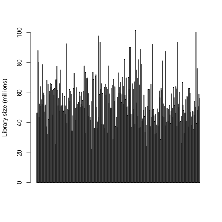

```r
barplot(d.filt$samples$lib.size*1e-6, ylab="Library size (millions)")
```

### Normalize the Data

```r
# Calculate normalization factors to scale the library
d.filt <- calcNormFactors(d.filt)
# Estimate common, trended, and then tagwise dispersions in one run
d.filt <- estimateDisp(d.filt, design)
```

### plot the biological coefficient of variation

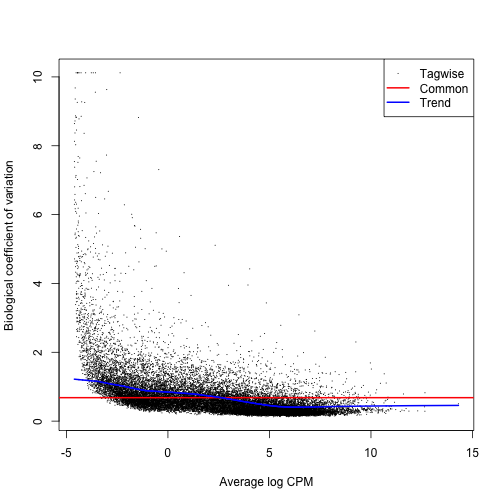

```r
plotBCV(d.filt)
```

### Make an MDS plot

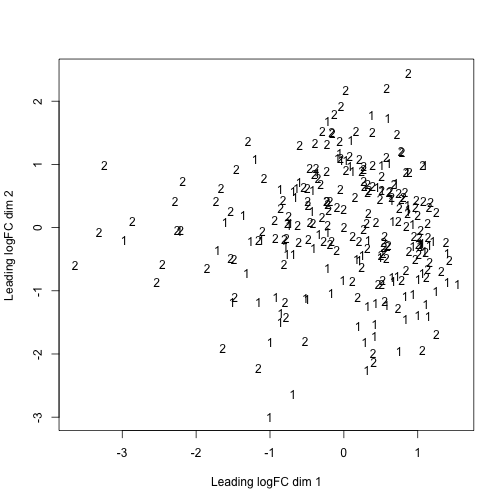

```r
plotMDS(d.filt, pch = 16, labels = as.numeric(samples$Type))
```

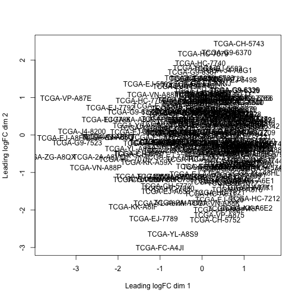

```r
mds <- plotMDS(d.filt)
```

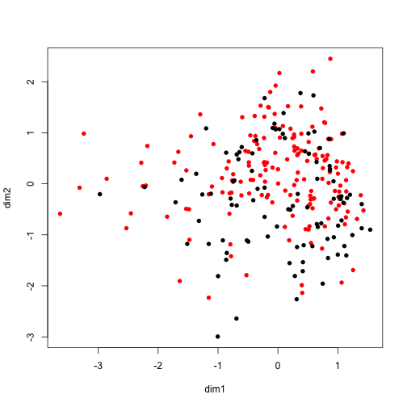

```r
plot(mds,pch = 16, col= samples$Type, xlab = "dim1",ylab = "dim2")
```

- x- and y-axes will be representative of Euclidean distances between your samples.
- These Euclidean distances will be produced/repeated across multiple dimensions in different ways

### Differential Expression Analysis

```r
#the first group is baseline
et<-exactTest(d.filt,c("low","high"))
topTags(et)
```

```
Comparison of groups:  high-low
                    logFC     logCPM       PValue          FDR
ENSG00000168505  5.505245 -1.2969014 1.700429e-40 4.000259e-36
ENSG00000261678  3.138630 -1.8824331 8.292590e-39 9.754159e-35
ENSG00000167244  3.132083  6.3595615 8.887182e-37 6.969032e-33
ENSG00000129990  2.918731 -1.0464215 1.270540e-29 7.472366e-26
ENSG00000175832 -4.866400  5.6435064 4.394285e-28 2.067511e-24
ENSG00000163285  4.586958 -1.9654280 9.505556e-28 3.726970e-24
ENSG00000053438  3.017353  2.7307715 2.719504e-27 9.139475e-24
ENSG00000175063  1.618642  2.4149746 7.298697e-27 2.146273e-23
ENSG00000256148 -4.273862  1.1647698 5.736873e-26 1.306994e-22
ENSG00000108309  1.823040  0.8682131 6.441899e-26 1.306994e-22
```

### Summarize Results

```r
summary(summaryde <- decideTestsDGE(et, p=0.05))
```

```
       high-low
Down       2874
NotSig    15027
Up         5624
```

```r
summary(summaryde <- decideTestsDGE(et, p=0.05,lfc=1))
```

```
       high-low
Down        192
NotSig    22562
Up          771
```

### Correct p-values

```r
FDR <- p.adjust(et$table$PValue, method="BH")
table_et <- cbind(et$table,FDR)
```

### Save DEGs in a table

```r
table.de_et <- table_et[table_et$FDR<=0.05,]
#write.csv(table.de_et,file="de_PDAC_hilo_gleason.csv")
deg_FC <- table_et[table_et$FDR<=0.05 & abs(table_et$logFC)>=1,]
#write.csv(deg_FC,file="de_PDAC_hilo_gleason_FC2.csv")
```

### Make an MA plot

```r
labelled_points <- table_et[rownames(table.de_et),]

g <- ggplot(table_et , aes(y = logFC, x = logCPM)) +
  geom_point(shape = ".") +
  geom_point(colour = "red", data = labelled_points,shape = ".") +
  ggtitle("MAplot", subtitle = "high-low")
```

### Make an MA plot

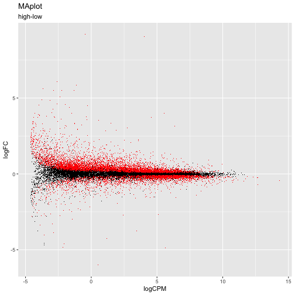

```r
print(g)
```

### Downstream analysis

- Observe in genome browser
- Annotate DEG
- Find biological processes that are enriched amongst the DEGs
- Pathway analysis
- Clustering analyses
- Biological Validation
- Network analyses

### Annotate genes using biomaRt

```r
library(biomaRt)
listMarts()
```

```
               biomart               version
1 ENSEMBL_MART_ENSEMBL      Ensembl Genes 98
2   ENSEMBL_MART_MOUSE      Mouse strains 98
3     ENSEMBL_MART_SNP  Ensembl Variation 98
4 ENSEMBL_MART_FUNCGEN Ensembl Regulation 98
```

```r
#choose ensembl dataset and filters to use
ensembl=useMart("ensembl")
ensembl = useMart(biomart = "ENSEMBL_MART_ENSEMBL",dataset="hsapiens_gene_ensembl", host = 'www.ensembl.org')
filters = listFilters(ensembl)
filters[1:5,]
```

```
             name              description
1 chromosome_name Chromosome/scaffold name
2           start                    Start
3             end                      End
4      band_start               Band Start
5        band_end                 Band End
```

### Annotate genes using biomaRt

```r
attributes = listAttributes(ensembl)
attributes[1:15,]
```

```
                            name                  description         page
1                ensembl_gene_id               Gene stable ID feature_page
2        ensembl_gene_id_version       Gene stable ID version feature_page
3          ensembl_transcript_id         Transcript stable ID feature_page
4  ensembl_transcript_id_version Transcript stable ID version feature_page
5             ensembl_peptide_id            Protein stable ID feature_page
6     ensembl_peptide_id_version    Protein stable ID version feature_page
7                ensembl_exon_id               Exon stable ID feature_page
8                    description             Gene description feature_page
9                chromosome_name     Chromosome/scaffold name feature_page
10                start_position              Gene start (bp) feature_page
11                  end_position                Gene end (bp) feature_page
12                        strand                       Strand feature_page
13                          band               Karyotype band feature_page
14              transcript_start        Transcript start (bp) feature_page
15                transcript_end          Transcript end (bp) feature_page
```

```r
filterOptions("ensembl_gene_id",ensembl)
```

```
[1] "[]"
```

### Annotate genes using biomaRt

```r
background_genes <- rownames(table_et)
degs <- rownames(table.de_et)

bckgd.annot <- getBM(attributes=c('ensembl_gene_id','hgnc_symbol',                                'entrezgene_id','description','external_gene_name',
                'chromosome_name','start_position','end_position','strand'),
                filters='ensembl_gene_id',values=background_genes,
                mart=ensembl)
```

### Annotate genes using biomaRt

```r
deg.annot <- getBM(attributes=c('ensembl_gene_id','hgnc_symbol','entrezgene_id',                  'description','external_gene_name','chromosome_name','start_position','end_position','strand'),
                filters='ensembl_gene_id', values=degs, mart=ensembl)
colnames(bckgd.annot)
```

```
[1] "ensembl_gene_id"    "hgnc_symbol"        "entrezgene_id"
[4] "description"        "external_gene_name" "chromosome_name"
[7] "start_position"     "end_position"       "strand"
```

### Annotate genes using biomaRt

```r
deg_ann.tb = merge(x = table_et, y = bckgd.annot, by.x="row.names",by.y='ensembl_gene_id',all.x=TRUE)
bckgd_ann.tb = merge(x = table.de_et, y = deg.annot, by.x="row.names",by.y='ensembl_gene_id',all.x=TRUE)
#write.csv(bckgd_ann.tb, file="allgenesAnnotation.csv")
#write.csv(deg_ann.tb, file="DEGAnnotation.csv")
```

### Perform a pathway analysis and enrichment analysis

```r
library(enrichplot)
library(clusterProfiler)
library(org.Hs.eg.db)
```

### Gene Ontology

- Ontology: a structured vocabulary
  - Describes concepts that exist in an area of knowledge
  - Describes relationships that exist
- Gene Ontology (GO):
  - Describes possible functions of genes
  - Describes relationships between genes
  - Describes where in the cell gene products are localized
- GO is independent of organism!

### Gene Ontology

- structure: DAG
  - directed acyclic graph
- relationships:
  - is a
  - has a
  - part of

[figure not shown]

### Perform a GO enrichment analysis

```r
cc.go <- enrichGO(gene          = deg_ann.tb$entrezgene_id,
                OrgDb         = org.Hs.eg.db,
                ont           = "CC",
                pAdjustMethod = "BH",
                qvalueCutoff  = 0.05,
                readable      = TRUE)
head(cc.go)
```

```
                   ID                      Description GeneRatio   BgRatio
GO:0030055 GO:0030055          cell-substrate junction 410/15826 412/19717
GO:0005924 GO:0005924 cell-substrate adherens junction 406/15826 408/19717
GO:0005925 GO:0005925                   focal adhesion 403/15826 405/19717
GO:0010008 GO:0010008                endosome membrane 468/15826 479/19717
GO:0005759 GO:0005759             mitochondrial matrix 457/15826 469/19717
GO:0005774 GO:0005774                vacuolar membrane 403/15826 412/19717
                 pvalue     p.adjust       qvalue
GO:0030055 8.727243e-37 6.815977e-34 2.884583e-34
GO:0005924 2.104809e-36 8.219280e-34 3.478474e-34
GO:0005925 4.072408e-36 1.060183e-33 4.486793e-34
GO:0010008 8.895154e-32 1.736779e-29 7.350206e-30
GO:0005759 6.520861e-30 1.018559e-27 4.310632e-28
GO:0005774 6.174534e-28 8.037186e-26 3.401410e-26
                                                                                                                                                                                                                                                                                                            …
GO:0030055                                                                                                                                                                                                                                                                                                  …
GO:0005924                                                                                                                                                                                                                                                                                                  …
GO:0005925                                                                                                                                                                                                                                                                                                  …
GO:0010008 CFTR/SPPL2B/LAMP2/AP2B1/VPS41/BAIAP3/VTA1/STARD3NL/CLCN6/EHD…-DQB1/TMEM150B/ZNRF2/GPR62/WASHC1/RAP2B/GPR135/SLC9A9/ANXA2/AP2A2/TBK1/VPS33B/IRAK1/SORCS2/RAB11B/ATP6V0A2/HGS/IRF7/PMEL/ANKFY1/ATP6V0C/LAMP1/PIP5K1C/BACE1/TPCN1/LAMTOR4/KIR2DL4/LITAF/HLA-DRB1/GIMAP5/TLR7/HLA-DQA1/MVB12B/AP2A1/A…
GO:0005759                                                                                                                                                                                                  NDUFAF7/POLDIP2/NDUFAB1/PDK4/SLC25A5/ACSM3/PDK2/ELAC2/AASS/L…
GO:0005774                                                                                                                                                                                                                                                                                                  …
           Count
GO:0030055   410
GO:0005924   406
GO:0005925   403
GO:0010008   468
GO:0005759   457
GO:0005774   403
```

```r
#write.csv(cc.go,file="cc.go.csv")
```

### Perform a GO enrichment analysis

```r
bp.go <- enrichGO(gene          = deg_ann.tb$entrezgene_id,
                  OrgDb         = org.Hs.eg.db,
                  ont           = "BP",
                  pAdjustMethod = "BH",
                  qvalueCutoff  = 0.05,
                  readable      = TRUE)
head(bp.go)
```

```
                   ID
GO:0022604 GO:0022604
GO:0007265 GO:0007265
GO:0043161 GO:0043161
GO:0010498 GO:0010498
GO:0006914 GO:0006914
GO:0061919 GO:0061919
                                                                 Description
GO:0022604                                  regulation of cell morphogenesis
GO:0007265                                   Ras protein signal transduction
GO:0043161 proteasome-mediated ubiquitin-dependent protein catabolic process
GO:0010498                             proteasomal protein catabolic process
GO:0006914                                                         autophagy
GO:0061919                            process utilizing autophagic mechanism
           GeneRatio   BgRatio       pvalue     p.adjust       qvalue
GO:0022604 476/15108 484/18670 6.545194e-34 4.230159e-30 2.215031e-30
GO:0007265 440/15108 448/18670 8.785327e-31 2.838978e-27 1.486570e-27
GO:0043161 413/15108 419/18670 1.522027e-30 3.278953e-27 1.716953e-27
GO:0010498 466/15108 477/18670 4.065504e-30 6.568837e-27 3.439630e-27
GO:0006914 482/15108 496/18670 7.697369e-29 8.291349e-26 4.341586e-26
GO:0061919 482/15108 496/18670 7.697369e-29 8.291349e-26 4.341586e-26
                                                                                                                                                                                                                                                                                                            …
GO:0022604                                                                                                                                                                                  FGR/SEMA3F/HECW1/SARM1/PLXND1/ARHGAP33/DVL2/MYCBP2/TNFRSF12A…-GPRASP2/PPP1R9A/DMTN/CDC42SE2/EPB41/ARHGAP35/KALRN…
GO:0007265                                                                                                                                                                                                                                                                                                  …
GO:0043161                                                                                                                                                                                                                                                                                                  …
GO:0010498                                                                                                                                                                                    GCLC/ANKIB1/HECW1/CDC27/FBXL3/OSBPL7/RHBDF1/PSMB1/PKD1/POMT2…-AS1-EDEM2/NSFL1C/ANAPC5/MAEA/PSME1/RFFL/CDC23/PS…
GO:0006914 BAD/POLDIP2/LAMP2/OSBPL7/VPS41/VTA1/DCN/CAPN1/HGF/RB1CC1/RRA…
GO:0061919 BAD/POLDIP2/LAMP2/OSBPL7/VPS41/VTA1/DCN/CAPN1/HGF/RB1CC1/RRA…
           Count
GO:0022604   476
GO:0007265   440
GO:0043161   413
GO:0010498   466
GO:0006914   482
GO:0061919   482
```

```r
#write.csv(bp.go,file="bp.go.csv")
```

### Perform a GO enrichment analysis

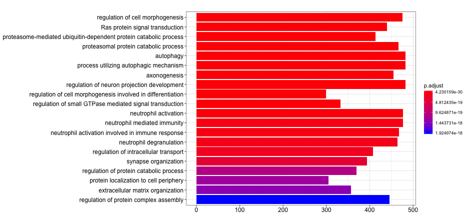

```r
barplot(bp.go, showCategory=20)
```

### Perform a GO enrichment analysis

```r
mf.go <- enrichGO(gene          = deg_ann.tb$entrezgene_id,
                  OrgDb         = org.Hs.eg.db,
                  ont           = "MF",
                  pAdjustMethod = "BH",
                  qvalueCutoff  = 0.05,
                  readable      = TRUE)
head(mf.go)
```

```
                   ID                                 Description GeneRatio
GO:0050839 GO:0050839              cell adhesion molecule binding 493/15137
GO:0045296 GO:0045296                            cadherin binding 328/15137
GO:0004674 GO:0004674    protein serine/threonine kinase activity 427/15137
GO:0003779 GO:0003779                               actin binding 416/15137
GO:0031267 GO:0031267                        small GTPase binding 425/15137
GO:0019787 GO:0019787 ubiquitin-like protein transferase activity 392/15137
             BgRatio       pvalue     p.adjust       qvalue
GO:0050839 499/17697 2.594115e-26 3.107749e-23 2.348357e-23
GO:0045296 331/17697 6.634980e-19 3.974353e-16 3.003202e-16
GO:0004674 439/17697 5.250043e-17 2.096517e-14 1.584224e-14
GO:0003779 431/17697 2.206193e-14 6.607548e-12 4.992963e-12
GO:0031267 443/17697 4.257279e-13 8.551020e-11 6.461539e-11
GO:0019787 407/17697 4.282648e-13 8.551020e-11 6.461539e-11
                                                                                                                                                                                                                                                                                                            …
GO:0050839 LASP1/ITGAL/ITGA3/CX3CL1/BAIAP2L1/PROM1/ADAM22/TENM1/CD9/NIS…-10/RAB11B/P4HB/MRTFB/SHTN1/ISG15/RPL14/HMGB1/PTPRT/NLGN3/PTP…
GO:0045296                                                                                                                                                                                                                                                                                                  …
GO:0004674                                                                                                                                                                                                                                                                                                  …
GO:0003779                                                                                                                                                                                                                                                                                                  …
GO:0031267                                                                                              ALS2/DVL2/MYCBP2/FARP2/ARHGAP44/NOX1/CDKL5/PLEKHG6/RANBP9/AN…-LOC100130357/DAAM2/FGD2/TIAM2/DENND2A/SYTL5/DIAPH2/DOCK11/C9…
GO:0019787                                                                                                                                                                                                                                                                                                  …
           Count
GO:0050839   493
GO:0045296   328
GO:0004674   427
GO:0003779   416
GO:0031267   425
GO:0019787   392
```

```r
#write.csv(bp.go,file="mf.go.csv")
```

### Perform a KEGG pathway enrichment analysis

```r
kk <- enrichKEGG(gene         = deg_ann.tb$entrezgene_id,
                 organism     = 'hsa',
                 pAdjustMethod = "BH",
                 qvalueCutoff  = 0.05)
head(kk)
```

```
               ID                    Description GeneRatio  BgRatio
hsa04510 hsa04510                 Focal adhesion  198/6809 199/7946
hsa04360 hsa04360                  Axon guidance  180/6809 181/7946
hsa04144 hsa04144                    Endocytosis  243/6809 249/7946
hsa04010 hsa04010         MAPK signaling pathway  284/6809 295/7946
hsa04722 hsa04722 Neurotrophin signaling pathway  119/6809 119/7946
hsa04150 hsa04150         mTOR signaling pathway  151/6809 153/7946
               pvalue     p.adjust       qvalue
hsa04510 1.041735e-12 3.354385e-10 1.546153e-10
hsa04360 1.643594e-11 2.646186e-09 1.219720e-09
hsa04144 9.927879e-11 1.065592e-08 4.911687e-09
hsa04010 1.086962e-09 8.750041e-08 4.033200e-08
hsa04722 9.004526e-09 5.798915e-07 2.672922e-07
hsa04150 1.566294e-08 8.405780e-07 3.874518e-07
                                                                                                                                                                                                                                                                                                            …
hsa04510                                                                                                                                                                                                                                                                                                    …
hsa04360                                                                                                                                                                                                                                                                                                    …
hsa04144                                                                                                           381/163/9265/51534/30845/30846/6642/9135/9765/1175/116984/55…
hsa04010 9020/8913/9254/23542/5536/8491/3479/3082/355/5606/2324/4254/…
hsa04722                                                                                                                                                                                                                                                                                                    …
hsa04150                                                                                                                                                                                                                                                                                                    …
         Count
hsa04510   198
hsa04360   180
hsa04144   243
hsa04010   284
hsa04722   119
hsa04150   151
```

```r
#write.csv(kk,file="enrichedKeggPathways.csv")
```

### Perform a KEGG pathway enrichment analysis

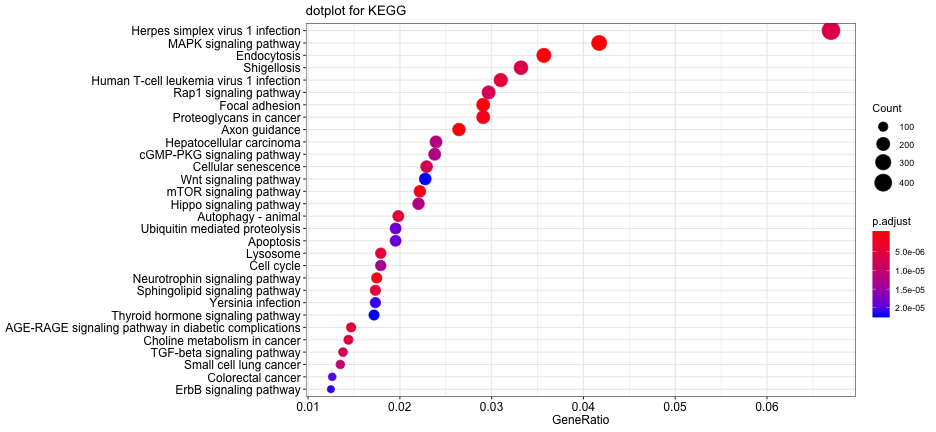

```r
dotplot(kk, showCategory=30) + ggtitle("dotplot for KEGG")
```